LOADING AND PREPROCESSING THE DATA

Here we are going load the data.

```r
setwd("C:/Users/Sara/Desktop/Coursera/ReproducibleResearch/CourseProject/repdata-data-activity")
dat<-read.csv("activity.csv",header = TRUE,sep = ",", stringsAsFactors=FALSE, dec=".")
```

MEAN TOTAL NUMBER OF STEPS TAKEN PER DAY

1. Steps taken per day

```r
datsinna<-na.omit(dat)
library(plyr)
nsteps<- ddply(datsinna, .(date),summarise,Totalsteps = sum(steps, na.rm = TRUE))
```

The main difference between bar charts and histograms is that With bar charts, each column represents a group defined by a categorical variable; and with histograms, each column represents a group defined by a quantitative variable. One implication of this distinction: it is always appropriate to talk about the skewness of a histogram; that is, the tendency of the observations to fall more on the low end or the high end of the X axis. With bar charts, however, the X axis does not have a low end or a high end; because the labels on the X axis are categorical - not quantitative. As a result, it is less appropriate to comment on the skewness of a bar chart.

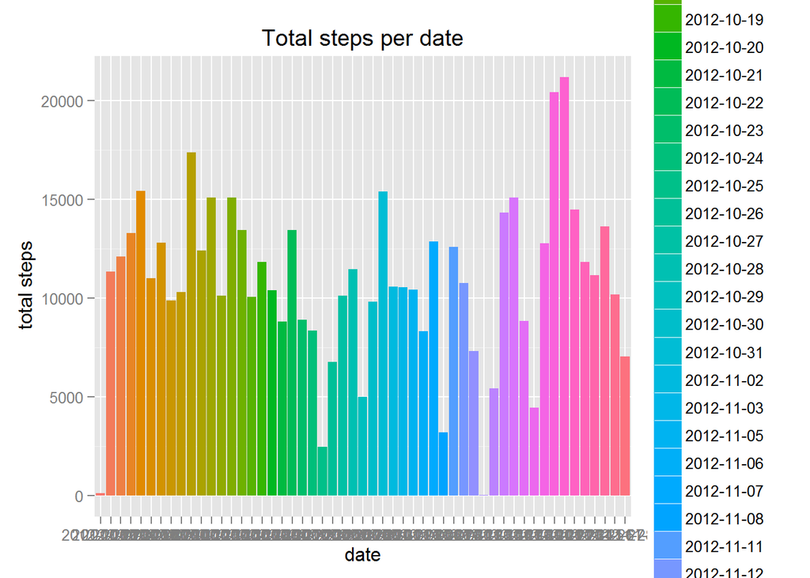

```r
library(ggplot2)
ggp <- ggplot(nsteps, aes(x=factor(nsteps$date), y=nsteps$Totalsteps, fill=city)) +geom_bar(aes(fill=nsteps$date),stat="identity") +labs(x="date", y=expression("total steps")) + labs(title=expression("Total steps per date"))
print(ggp)
```

```r
meansteps<- ddply(datsinna, .(date),summarise,Totalsteps = mean(steps, na.rm = TRUE))
mediansteps<- ddply(datsinna, .(date),summarise,Totalsteps = median(steps, na.rm = TRUE))
```

AVERAGE DAILY ACTIVITY PATTERN

1.Make a time series plot (i.e. type = “l”) of the 5-minute interval (x-axis) and the average number of steps taken, averaged across all days (y-axis)

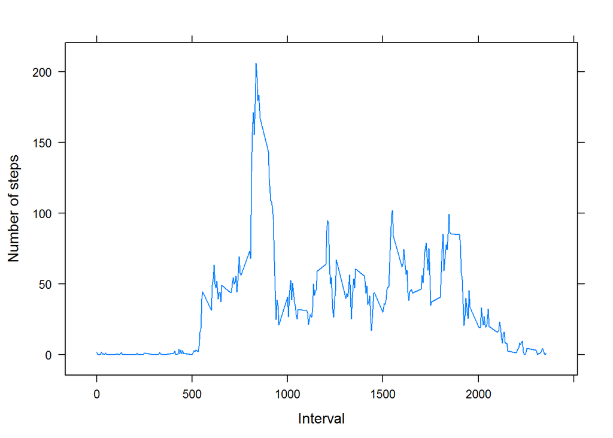

```r
steps.interval <- aggregate(steps ~ interval, data=datsinna, FUN=mean)
library(lattice)
xyplot(steps ~ interval, steps.interval, type = "l",
    xlab = "Interval", ylab = "Number of steps")
```

2. Which 5-minute interval, on average across all the days in the dataset, contains the maximum number of steps?

```r
steps.interval$interval[which.max(steps.interval$steps)]
```

```
## [1] 835
```

IMPUTING MISSING VALUES

```r
nmissingvalue<-sum(is.na(dat))
```

2.Devise a strategy for filling in all of the missing values in the dataset. The strategy does not need to be sophisticated. For example, you could use the mean/median for that day, or the mean for that 5-minute interval, etc.

3.Create a new dataset that is equal to the original dataset but with the missing data filled in.

```r
dat <- merge(dat, steps.interval, by="interval", suffixes=c("",".y"))
nas <- is.na(dat$steps)
dat$steps[nas] <- dat$steps.y[nas]
dat <- dat[,c(1:3)]
```

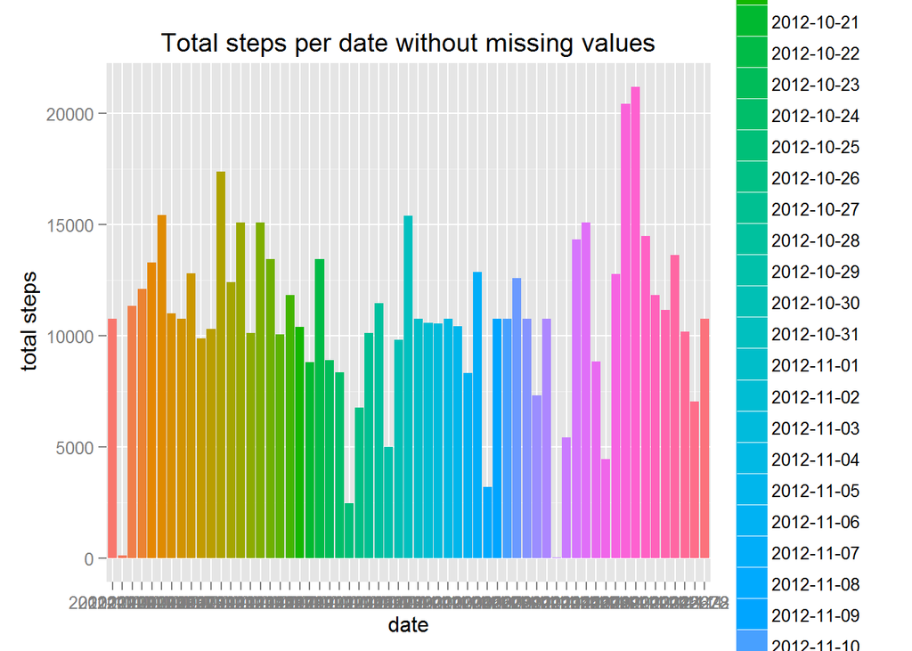

```r
n2steps<- ddply(dat, .(date),summarise,Totalsteps = sum(steps, na.rm = TRUE))
ggp <- ggplot(n2steps, aes(x=factor(n2steps$date), y=n2steps$Totalsteps, fill=city)) +geom_bar(aes(fill=n2steps$date),stat="identity") +labs(x="date", y=expression("total steps")) + labs(title=expression("Total steps per date without missing values"))
print(ggp)
```

```r
mean2steps<- ddply(dat, .(date),summarise,Totalsteps = mean(steps, na.rm = TRUE))
median2steps<- ddply(dat, .(date),summarise,Totalsteps = median(steps, na.rm = TRUE))
```

DIFFERENCES BETWEEN WEEKENDS AND WEEKDAYS

1. Create a new factor variable in the dataset with two levels - “weekday” and “weekend” indicating whether a given date is a weekday or weekend day.

```r
day <- weekdays(as.Date(dat$date))
daylevel <- vector()
for (i in 1:nrow(dat)) {
    if (day[i] == "sábado") {
        daylevel[i] <- "Weekend"
    } else if (day[i] == "domingo") {
        daylevel[i] <- "Weekend"
    } else {
        daylevel[i] <- "Weekday"
    }
}
dat$daylevel <- daylevel
dat$daylevel <- factor(dat$daylevel)
```

2. Make a panel plot containing a time series plot (i.e. type = “l”) of the 5-minute interval (x-axis) and the average number of steps taken, averaged across all weekday days or weekend days (y-axis). See the README file in the GitHub repository to see an example of what this plot should look like using simulated data.

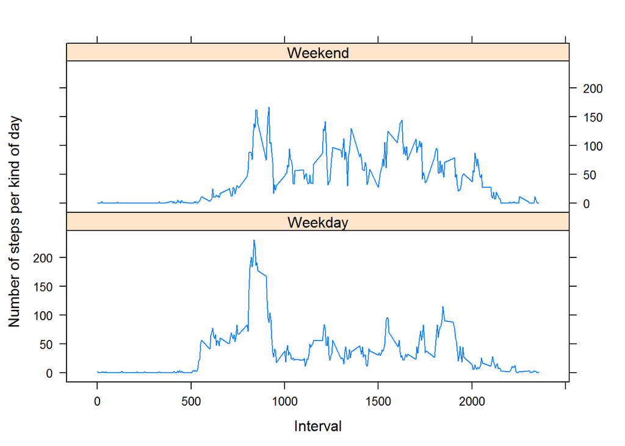

```r
steps.interval.day <- aggregate(steps ~ interval+daylevel, data=dat, FUN=mean)
library(lattice)
xyplot(steps ~ interval | daylevel, steps.interval.day, type = "l", layout = c(1, 2), xlab = "Interval", ylab = "Number of steps per kind of day")
```